# Analyis of Vertebral Data using GLM

by Eric Lee

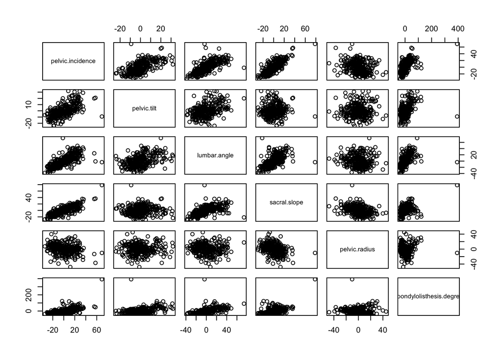

```r
#Load data and process
vertebral.data <- read.csv("vertebral.csv")
norm.or.abnorm = rep(0, 310)
norm.or.abnorm[vertebral.data$class == "Abnormal"] = 1
vertebral <- data.frame(pelvic.incidence = vertebral.data$pelvic_incidence - mean(vertebral.data$pelvic_incidence),
                        pelvic.tilt = vertebral.data$pelvic_tilt - mean(vertebral.data$pelvic_tilt),
                        lumbar.angle = vertebral.data$lumbar_lordosis_angle - mean(vertebral.data$lumbar_lordosis_angle),
                        sacral.slope = vertebral.data$sacral_slope - mean(vertebral.data$sacral_slope),
                        pelvic.radius = vertebral.data$pelvic_radius - mean(vertebral.data$pelvic_radius),
                        spondylolisthesis.degree = vertebral.data$degree_spondylolisthesis - mean(vertebral.data$degree_spondylolisthesis),
                        class = norm.or.abnorm)

plot(vertebral[1:6])
```

```r
#Fitting linear models to select right features
vertebral.fit.glm <- glm(class ~ pelvic.incidence + pelvic.tilt + lumbar.angle + sacral.slope + pelvic.radius + spondylolisthesis.degree, data = vertebral, family = binomial)
summary(vertebral.fit.glm)
```

```
##
## Call:
## glm(formula = class ~ pelvic.incidence + pelvic.tilt + lumbar.angle +
##     sacral.slope + pelvic.radius + spondylolisthesis.degree,
##     family = binomial, data = vertebral)
##
## Deviance Residuals:
##     Min       1Q   Median       3Q      Max
## -2.7317  -0.4081   0.0289   0.3639   2.2678
##
## Coefficients:
##                            Estimate Std. Error z value Pr(>|z|)
## (Intercept)               3.216e+00  4.803e-01   6.696 2.14e-11 ***
## pelvic.incidence         -2.517e+07  4.017e+07  -0.627    0.531
## pelvic.tilt               2.517e+07  4.017e+07   0.627    0.531
## lumbar.angle             -1.794e-02  2.290e-02  -0.784    0.433
## sacral.slope              2.517e+07  4.017e+07   0.627    0.531
## pelvic.radius            -1.077e-01  2.318e-02  -4.645 3.39e-06 ***
## spondylolisthesis.degree  1.693e-01  2.335e-02   7.248 4.23e-13 ***
## ---
## Signif. codes:  0 '***' 0.001 '**' 0.01 '*' 0.05 '.' 0.1 ' ' 1
##
## (Dispersion parameter for binomial family taken to be 1)
##
##     Null deviance: 389.86  on 309  degrees of freedom
## Residual deviance: 177.87  on 303  degrees of freedom
## AIC: 191.87
##
## Number of Fisher Scoring iterations: 8
```

From the graph above, we can see that some features are highly correlated with one another. This intuitively makes sense, as the lower back is interconnected and works in a mechanical way.

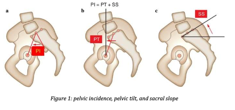

figure1

The strange output can be explained by figure 1. It turns out, pelvic incidence is just the sum of the pelvic tilt and sacral slope. So essentially, we are measuring the same value twice making it redundant. Therefore, we will update our model by dropping pelvic incidence and lumbar angle.

```r
#Dropping pelvic incidence and lumbar angle
vertebral.fit.glm3 <- glm(class ~ pelvic.tilt + sacral.slope + pelvic.radius + spondylolisthesis.degree, data = vertebral, family = binomial)
summary(vertebral.fit.glm3)
```

```
##
## Call:
## glm(formula = class ~ pelvic.tilt + sacral.slope + pelvic.radius +
##     spondylolisthesis.degree, family = binomial, data = vertebral)
##
## Deviance Residuals:
##     Min       1Q   Median       3Q      Max
## -2.7927  -0.4019   0.0319   0.3795   2.2198
##
## Coefficients:
##                          Estimate Std. Error z value Pr(>|z|)
## (Intercept)               3.18805    0.47683   6.686 2.29e-11 ***
## pelvic.tilt               0.06647    0.02925   2.272   0.0231 *
## sacral.slope             -0.11495    0.02266  -5.072 3.94e-07 ***
## pelvic.radius            -0.10893    0.02279  -4.780 1.75e-06 ***
## spondylolisthesis.degree  0.16541    0.02289   7.227 4.92e-13 ***
## ---
## Signif. codes:  0 '***' 0.001 '**' 0.01 '*' 0.05 '.' 0.1 ' ' 1
##
## (Dispersion parameter for binomial family taken to be 1)
##
##     Null deviance: 389.86  on 309  degrees of freedom
## Residual deviance: 178.94  on 305  degrees of freedom
## AIC: 188.94
##
## Number of Fisher Scoring iterations: 8
```

As we can see, dropping these features make all the others significant. Also, to note that the parameters for pelvic tilt and sacral slope are not identical anymore.

```r
#Interaction Terms
vertebral.fit.glm4 <- glm(class ~ pelvic.tilt + sacral.slope + pelvic.radius + spondylolisthesis.degree + pelvic.tilt*sacral.slope, data = vertebral, family = binomial)
vertebral.fit.glm5 <- glm(class ~ pelvic.tilt + sacral.slope + pelvic.radius + spondylolisthesis.degree + pelvic.tilt*pelvic.radius, data = vertebral, family = binomial)
vertebral.fit.glm6 <- glm(class ~ pelvic.tilt + sacral.slope + pelvic.radius + spondylolisthesis.degree + pelvic.tilt*spondylolisthesis.degree, data = vertebral, family = binomial)
vertebral.fit.glm7 <- glm(class ~ pelvic.tilt + sacral.slope + pelvic.radius + spondylolisthesis.degree + sacral.slope*pelvic.radius, data = vertebral, family = binomial)
vertebral.fit.glm8 <- glm(class ~ pelvic.tilt + sacral.slope + pelvic.radius + spondylolisthesis.degree + sacral.slope*spondylolisthesis.degree, data = vertebral, family = binomial)
vertebral.fit.glm9 <- glm(class ~ pelvic.tilt + sacral.slope + pelvic.radius + spondylolisthesis.degree + pelvic.radius*spondylolisthesis.degree, data = vertebral, family = binomial)
#Matrix of AIC interaction terms
row.names <- c("pelvic.tilt", "sacral.slope", "pelvic.radius", "spondylolisthesis.degree")
column.names <- c("pelvic.tilt", "sacral.slope", "pelvic.radius", "spondylolisthesis.degree")
mat <- c(0, AIC(vertebral.fit.glm4), AIC(vertebral.fit.glm5), AIC(vertebral.fit.glm6),
        AIC(vertebral.fit.glm4), 0 , AIC(vertebral.fit.glm7), AIC(vertebral.fit.glm8),
        AIC(vertebral.fit.glm5), AIC(vertebral.fit.glm7), 0, AIC(vertebral.fit.glm9),
        AIC(vertebral.fit.glm6), AIC(vertebral.fit.glm8), AIC(vertebral.fit.glm9), 0)

named_matrix <- matrix(mat, nrow=4, byrow=TRUE, dimnames=list(row.names, column.names))
named_matrix
```

```
##                          pelvic.tilt sacral.slope pelvic.radius
## pelvic.tilt                   0.0000     190.8427      190.4010
## sacral.slope                190.8427       0.0000      190.5201
## pelvic.radius               190.4010     190.5201        0.0000
## spondylolisthesis.degree    189.9562     183.8291      188.7804
##                          spondylolisthesis.degree
## pelvic.tilt                              189.9562
## sacral.slope                             183.8291
## pelvic.radius                            188.7804
## spondylolisthesis.degree                   0.0000
```

However, as mentioned earlier, the lower back works in a mechanical way and therefore interaction terms may be present. When we try different combinations of features, nearly all interactions increase the AIC apart from two, which is highlighted in the AIC matrix. This is just a matrix of AIC scores. The biggest decrease in AIC happens with the inclusion of sacral slope interacting with the degree of spondylolisthesis.

[figure not shown]

figure2

Bio mechanically this interaction makes sense. The LHS of figure 2 depicts spondylolisthesis. Essentially, spondylolisthesis happens when one of your lower vertebral slips out of place as shown by the yellow circle. The red lines in the RHS of figure 2 shows the sacral slope. We can see that as the sacral slope angle increases, the lower vertebral will move towards a more vertical position. Therefore, the probability of gravity pulling forward one of the disks increases and thereby getting spondylolisthesis.

```r
#Summary of Final model
summary(vertebral.fit.glm8)
```

```
##
## Call:
## glm(formula = class ~ pelvic.tilt + sacral.slope + pelvic.radius +
##     spondylolisthesis.degree + sacral.slope * spondylolisthesis.degree,
##     family = binomial, data = vertebral)
##
## Deviance Residuals:
##      Min        1Q    Median        3Q       Max
## -2.72491  -0.39572   0.01009   0.26768   2.36282
##
## Coefficients:
##                                        Estimate Std. Error z value Pr(>|z|)
## (Intercept)                            3.022399   0.563454   5.364 8.14e-08 ***
## pelvic.tilt                            0.071785   0.030491   2.354   0.0186 *
## sacral.slope                          -0.000337   0.054049  -0.006   0.9950
## pelvic.radius                         -0.098314   0.022756  -4.320 1.56e-05 ***
## spondylolisthesis.degree               0.167438   0.026418   6.338 2.33e-10 ***
## sacral.slope:spondylolisthesis.degree  0.005311   0.002284   2.325   0.0200 *
## ---
## Signif. codes:  0 '***' 0.001 '**' 0.01 '*' 0.05 '.' 0.1 ' ' 1
##
## (Dispersion parameter for binomial family taken to be 1)
##
##     Null deviance: 389.86  on 309  degrees of freedom
## Residual deviance: 171.83  on 304  degrees of freedom
## AIC: 183.83
##
## Number of Fisher Scoring iterations: 9
```

When we look at the summary output of this model, the interaction between sacral slope and degree of spondylolisthesis is significant. Therefore, this will be our final model.

By taking the inverse logit of the intercept we get 0.95 probability of being abnormal, which is a rather high probability. However, this could be due to the underlying data having uneven balances of normal and abnormal cases, as 2/3rd of the dataset is abnormal.

When we try to interpret the coefficient by taking the exp(coefficients), it will show the increase or decrease in odds of being abnormal. This means that the positive coefficients increase log odds by their respective exp(B_i) while the negative will have a decrease in odds.

[figure not shown]

figure3

Increase in pelvic tilt will increase odds of abnormality by exp (0.0717), which means the probability of a disk to slip forward goes up as shown in figure 3. An increase in pelvic radius will decrease abnormality. While increases in the degree of spondylolisthesis will increase probability of abnormalities, because it is a direct measure of slippage as shown previously.

All in all, increases in pelvic tilt and the curvature of the lower spine is likely to cause more abnormality. Thus, we should all strive to have proper posture to avoid lower back injuries.